# Hanukkah of Data

Short data challenge released over 8 days of Hanukkah in 2022

Julian During www.datannery.com  
2023-01-15

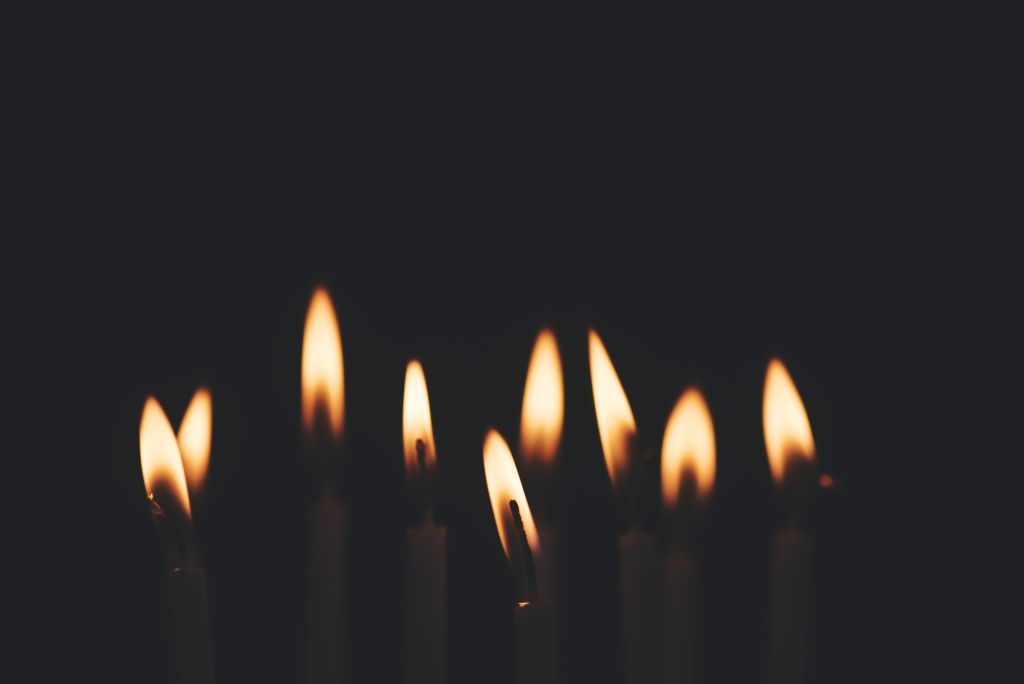

Title photo from [Gaelle Marcel](https://unsplash.com/@gaellemarcel?utm_source=unsplash&utm_medium=referral&utm_content=creditCopyText) on [Unsplash](https://unsplash.com/de/fotos/wkn_KHBExcE?utm_source=unsplash&utm_medium=referral&utm_content=creditCopyText)

# Challenge

‘Hanukkah of Data’ is a [data challenge](https://hanukkah.bluebird.sh/about/) where you have to solve 8 puzzles surrounding a fictional data set.

We are asked to find a rug for our granduncle Noah who owns a store. The store has data about customer, products and orders. With the help of the data ([CSV files](https://github.com/duju211/hanukkah_of_data/tree/master/csv)) we are asked to solve a total of eight puzzles.

# Data

The data for this analysis consists of four CSV files: ‘noahs-customers.csv’, ‘noahs-orders.csv’, ‘noahs-orders_items.csv’ and ‘noahs-products.csv’. The data is read into R with the help of the `readr::read_csv` function, specifying the correct column types as arguments in the function calls.

## Customers

There are a total of 11080 customers in the raw data. Perform the following preprocessing steps:

- Determine the Initials by splitting the name into first and last name
- Extract all digits from the phone number and save in column `phone_chr`
- Remove duplicates

```r
customers <- function(df_customers_raw) {
  df_customers_raw |>
    mutate(
      phone_chr = map_chr(str_extract_all(phone, "\\d"), str_flatten),
      name_split = str_split(name, "\\s+"),
      first_name = map_chr(name_split, ~ str_flatten(.x[.x != last(.x)])),
      last_name = map_chr(name_split, last),
      initials = str_to_lower(str_glue(
        "{str_sub(first_name, end = 1)}{str_sub(last_name, end = 1)}"))) |>
    select(where(negate(is_list))) |>
    distinct(customerid, .keep_all = TRUE)
}
```

```
# A tibble: 11,079 × 10
   customerid name     address citystatezip birthdate  phone phone_chr
   <chr>      <chr>    <chr>   <chr>        <date>     <chr> <chr>
 1 1001       Jack Qu… 201 E … Los Angeles… 1960-05-14 805-… 80528785…
 2 1002       David P… 224C T… Staten Isla… 1978-04-04 516-… 51676816…
 3 1003       Carrie … 1608 W… Tampa, FL 3… 1969-01-21 727-… 72720904…
 4 1004       Steven … 178½ E… Manhattan, … 1953-08-17 607-… 60794195…
 5 1005       Christi… 270 W … Bronx, NY 1… 1983-06-06 212-… 21275990…
 6 1006       Amanda … 183-48… Saint Alban… 1962-07-08 914-… 91442131…
 7 1007       Mark Co… 14-47 … College Poi… 1967-04-14 585-… 58555419…
 8 1008       Jill St… 735A A… Manhattan, … 1959-06-11 516-… 51630704…
 9 1009       Samuel … 56 Ric… Brooklyn, N… 1988-10-24 929-… 92986987…
10 1010       Brenda … 2821 B… Bronx, NY 1… 1960-09-07 914-… 91420526…
# ℹ 11,069 more rows
# ℹ 3 more variables: first_name <chr>, last_name <chr>,
#   initials <chr>
```

## Products

There are a total of 1124 products. Perform the following preprocessing:

```r
products <- function(df_products_raw) {
  df_products_raw |>
    mutate(
      category = str_remove(sku, "\\d+"),
      add_info = str_extract(desc, "\\(.+\\)"),
      desc = if_else(!is.na(add_info), str_remove(desc, add_info), desc),
      across(c(add_info, desc), ~ str_trim(str_remove_all(.x, "\\)|\\("))))
}
```

```
# A tibble: 1,124 × 5
   sku     desc                       wholesale_cost category add_info
   <chr>   <chr>                               <dbl> <chr>    <chr>
 1 DLI0002 Smoked Whitefish Sandwich            9.33 DLI      <NA>
 2 PET0005 Vegan Cat Food, Turkey & …           4.35 PET      <NA>
 3 HOM0018 Power Radio                         21.8  HOM      red
 4 KIT0034 Azure Ladle                          2.81 KIT      <NA>
 5 PET0041 Gluten-free Cat Food, Pum…           4.6  PET      <NA>
 6 PET0045 Gluten-free Cat Food, Sal…           4.32 PET      <NA>
 7 TOY0048 Electric Doll                       10.2  TOY      <NA>
 8 CMP0061 Network Printer                    136.   CMP      <NA>
 9 DLI0066 Pickled Herring Sandwich             9.94 DLI      <NA>
10 TOY0085 Noah's Toy Soldier                  12.0  TOY      <NA>
# ℹ 1,114 more rows
```

## Orders

There are a total of 214207 orders with 427258 items ordered. Join the ordered item as list column to make them easily accessible.

```r
orders <- function(df_orders_raw, df_order_items) {
  df_orders_raw |>
    select(-items) |>
    nest_join(df_order_items, by = "orderid", name = "items")
}
```

# Puzzles

## Puzzle 1

To find the rug, we will need to contact a private investigator. The last name of the investigator can be spelled by using the letters printed on the phone buttons. For example: 2 has “ABC”, and 3 “DEF”, etc.

The key pad of the phone can be represented in R like this:

```r
phone_letter <- function() {
  tibble(letter = letters) |>
    mutate(
      nr = ((row_number() - 1) %/% 3) + 2,
      nr = as.character(if_else(nr == 10, 0, nr)))
}
```

```
# A tibble: 26 × 2
   letter nr
   <chr>  <chr>
 1 a      2
 2 b      2
 3 c      2
 4 d      3
 5 e      3
 6 f      3
 7 g      4
 8 h      4
 9 i      4
10 j      5
# ℹ 16 more rows
```

By combining this representation with the data on hand, we can determine the investigator:

```r
investigator <- function(df_customers, df_phone_letter) {
  df_customers_pro <- df_customers |>
    transmute(
      name_pro = str_split(str_to_lower(str_remove_all(
        last_name, "\\s"), "\\s"), ""),
      customerid) |>
    unnest(name_pro) |>
    left_join(df_phone_letter, by = c("name_pro" = "letter")) |>
    group_by(customerid) |>
    summarise(phone_pro = str_flatten(nr))

  df_customers |>
    left_join(df_customers_pro, by = "customerid") |>
    filter(str_length(str_extract(phone_chr, phone_pro)) == str_length(phone_chr))
}
```

| customerid | name | phone |
| --- | --- | --- |
| 3188 | Sam Guttenberg | 488-836-2374 |

## Puzzle 2

Now we are looking for a contractor, to whom the rug was given to by a cleaning company. The following is known:

- The contractor has the initials ‘jd’
- The cleaning company and the contractor had meetings at Noah’s over coffee and bagels
- The cleaning company stopped outsourcing a few years ago

```r
contractor <- function(df_orders, df_customers, coffee_bagel_regex) {
  df_customers_after_2017 <- df_orders |>
    filter(year(ordered) > 2017) |>
    distinct(customerid)

  df_rel_orders <- df_orders |>
    filter(year(ordered) <= 2017) |>
    anti_join(df_customers_after_2017, by = "customerid") |>
    unnest(items) |>
    filter(str_detect(desc, coffee_bagel_regex)) |>
    semi_join(filter(df_customers, initials == "jd"), by = "customerid")

  df_customers |>
    semi_join(df_rel_orders, by = "customerid")
}
```

| customerid | name | citystatezip | phone |
| --- | --- | --- | --- |
| 4164 | Jeremy Davis | South Ozone Park, NY 11420 | 212-771-8924 |

## Puzzle 3

We are searching for the neighbor of the contractor. The neighbor has the following characteristics:

Dog years are determined by the following function:

```r
det_dog_years <- function() {
  2018 - (1:9 * 12)
}
```

Resulting in: 2006, 1994, 1982, 1970, 1958, 1946, 1934, 1922, 1910

With this information we can find out who the neighbor is:

```r
spider_hat <- function(df_customers, df_contractor, dog_years) {
  df_customers |>
    filter(year(birthdate) %in% dog_years) |>
    filter(
      case_when(
        month(birthdate) == 3 ~ day(birthdate) >= 21,
        month(birthdate) == 4 ~ day(birthdate) <= 20,
        TRUE ~ FALSE)) |>
    filter(str_detect(citystatezip, df_contractor$citystatezip))
}
```

| customerid | name | citystatezip | birthdate | phone |
| --- | --- | --- | --- | --- |
| 2274 | Brent Nguyen | South Ozone Park, NY 11420 | 1958-03-25 | 516-636-7397 |

## Puzzle 4

The next persons has the following habit:

- Claims the first pastries of the day

Filter products for the ‘BKY’ category and search for the person which always orders these products first:

```r
tinder_woman <- function(df_products, df_orders, df_customers,
                         product_pastries) {
  df_products_pastries <- df_products |>
    filter(category == product_pastries)

  df_orders_pastries <- df_orders |>
    unnest(items) |>
    semi_join(df_products_pastries, by = "sku")

  df_first_pastries <- df_orders_pastries |>
    mutate(day = floor_date(ordered, unit = "day")) |>
    group_by(day) |>
    filter(ordered == min(ordered)) |>
    ungroup() |>
    count(customerid, sort = TRUE)

  df_customers |>
    semi_join(slice(df_first_pastries, 1), by = "customerid")
}
```

| customerid | name | phone |
| --- | --- | --- |
| 5375 | Christina Booker | 718-649-9036 |

## Puzzle 5

In the 5th puzzle we need to find a lady with a lot of cats as pets. We know about her and her pets:

- The cats are senior
- She lives in Queens
- She has a lot of cats

```r
cat_lady <- function(df_products, df_orders, df_customers) {
  df_products_cat <- df_products |>
    filter(str_detect(desc, regex("cat", ignore_case = TRUE))) |>
    filter(str_detect(desc, regex("senior", ignore_case = TRUE)))

  df_customers_queens <- df_customers |>
    filter(str_detect(citystatezip, regex("queens", ignore_case = TRUE)))

  df_customer_id <- df_orders |>
    semi_join(df_customers_queens, by = "customerid") |>
    unnest(items) |>
    semi_join(df_products_cat, by = "sku") |>
    group_by(customerid) |>
    summarise(sku = str_flatten(unique(sku), ", "), anz = n()) |>
    filter(anz > 2)

  df_customers |>
    semi_join(df_customer_id, by = "customerid")
}
```

| customerid | name | phone |
| --- | --- | --- |
| 7675 | Anita Koch | 315-492-7411 |

## Puzzle 6

The cat lady has a very frugal cousin. She tells us: *” Noah […] loses money whenever she comes in the store”:*

```r
frugal_cousin <- function(df_orders, df_customers) {
  df_customer_id <- df_orders |>
    mutate(
      profit = map_dbl(items, ~ sum(.x$unit_price - .x$wholesale_cost))) |>
    group_by(customerid) |>
    summarise(profit = sum(profit)) |>
    top_n(n = 1, wt = -profit)

  df_customers |>
    semi_join(df_customer_id, "customerid")
}
```

| customerid | name | phone |
| --- | --- | --- |
| 8342 | Emily Randolph | 914-868-0316 |

## Puzzle 7

The frugal cousin tells us how she met her ex-boyfriend. They met while they were buying the same product, but in different colors. So we look at all the orders from the frugal cousin and search for that incident:

```r
ex_boyfriend <- function(df_frugal_cousin, df_orders, df_customers) {
  df_orders_color <- df_orders |>
    semi_join(df_frugal_cousin, by = "customerid") |>
    unnest(items) |>
    mutate(day = floor_date(ordered, "day")) |>
    filter(!is.na(add_info))

  df_order_rel <- df_orders |>
    mutate(day = floor_date(ordered, "day")) |>
    semi_join(df_orders_color, by = "day") |>
    unnest(items) |>
    inner_join(
      df_orders_color, by = c("desc", "day"),
      suffix = c("_male", "_female")) |>
    filter(
      add_info_male != add_info_female,
      ordered_male >= ordered_female - dminutes(10)
      & ordered_male <= ordered_female + dminutes(10))

  df_customers |>
    semi_join(df_order_rel, by = c("customerid" = "customerid_male"))
}
```

| customerid | name | phone |
| --- | --- | --- |
| 8835 | Jonathan Adams | 315-618-5263 |

## Puzzle 8

Finally, we search for a collector. The collector is in possession of a complete set of Noah’s collectibles. By looking at the data, the relevant category is ‘COL’:

```r
collector <- function(df_products, df_orders, df_customers, product_collect) {
  df_products_collect <- df_products |>
    filter(category == product_collect)

  df_orders_unnested <- df_orders |>
    unnest(items)

  df_customer_id <- df_orders_unnested |>
    semi_join(df_products_collect, by = c("sku")) |>
    group_by(customerid) |>
    summarise(anz_col = n_distinct(sku)) |>
    arrange(desc(anz_col)) |>
    slice(1)

  df_customers |>
    semi_join(df_customer_id, by = "customerid")
}
```

| customerid | name | phone |
| --- | --- | --- |
| 4308 | Travis Bartlett | 929-906-5980 |

# End

Participating in the “Hanukkah of Data” competition was both challenging and rewarding. We successfully solved 8 difficult puzzles, sharpening our problem-solving and coding skills. I look forward to the challenge again next year and am eager to see what it holds.